# HWS in R Studio

Cole Chisamore

2025-11-11

# 1 Introduction

In this pdf, I will using R to attempt to model the response variable housing price based on multiple explanatory variables:

- Bedrooms: Number of bedrooms in the property (main or otherwise)
- Bathrooms: Number of bathrooms in the property (main or otherwise)
- Square Feet: Rough square footage of indoor property
- Property Type: Category assigned to each listing including…
  - Apt/Condo
  - Duplex
  - Fourplex
  - House
  - Land/Lot
  - Mfd/Mobile Home
  - Multifamily
  - Recreational
  - Townhouse
  - Triplex

# 2 Forming the Initial Model

I will begin with a naive model after reading in the scraped data. However I will first remove duplicates and invalid responses, and factorize Property Type. The model will be a basic generalized linear model correlating Price with each explanatory variable.

```r
library(tidyverse)
library(forcats)
library(car)
library(rstatix)
## Polishing and Sampling dataframe:
houses.df <- read_csv(file = "housing_df.csv", show_col_types = FALSE)
houses.df <- houses.df %>% drop_na() %>% distinct()
houses.df$`Property Type` <- factor(houses.df$`Property Type`)
houses.df <- houses.df %>% mutate(`Property Type` = fct_reorder(
  `Property Type`, Price, .fun="length", .desc = TRUE))
houses.df <- houses.df %>% rename(PropertyType = `Property Type`)
houses.df <- houses.df %>% rename(SquareFeet = `Square Feet`)
## Creating first model:
houses.glm1 <- glm(formula = Price~Bedrooms+Bathrooms+SquareFeet+PropertyType+Province+Population,
                   data=houses.df)
#' Prints a concise summary of model
#'
#' @param model A linear model
#' @param name String
my_summary <- function(model, name="Unnamed Model"){
  cat("\"",name,"\"\n")
  cat("Formula: ",as.character(model$formula)[c(2,1,3)],"\n \n")
  printCoefmat(summary(model)$coefficients)
  cat(paste("\nAIC:", model$aic))}
my_summary(houses.glm1, "Naive Model")
```

```
## " Naive Model "
## Formula:  Price ~ Bedrooms + Bathrooms + SquareFeet + PropertyType + Province + Population
##
##                                Estimate  Std. Error  t value  Pr(>|t|)
## (Intercept)                 -2.2020e+05  1.9595e+04 -11.2380 < 2.2e-16 ***
## Bedrooms                    -5.8031e+04  4.6349e+03 -12.5205 < 2.2e-16 ***
## Bathrooms                    5.4590e+04  6.4666e+03   8.4419 < 2.2e-16 ***
## SquareFeet                   5.2226e+02  8.9240e+00  58.5228 < 2.2e-16 ***
## PropertyTypeApt/Condo       -1.7315e+05  1.5210e+04 -11.3844 < 2.2e-16 ***
## PropertyTypeTownhouse       -2.2418e+05  1.5508e+04 -14.4559 < 2.2e-16 ***
## PropertyTypeDuplex          -2.2883e+04  2.6497e+04  -0.8636  0.387824
## PropertyTypeMfd/Mobile Home -3.7967e+05  5.3225e+04  -7.1333  1.04e-12 ***
## PropertyTypeMultifamily     -1.2180e+05  6.4410e+04  -1.8911  0.058638 .
## PropertyTypeFourplex        -5.2007e+05  1.5805e+05  -3.2905  0.001003 **
## PropertyTypeLand/Lot        -2.3187e+05  1.6555e+05  -1.4006  0.161357
## PropertyTypeTriplex         -2.4287e+05  1.7451e+05  -1.3917  0.164033
## PropertyTypeRecreational    -1.0637e+05  3.0186e+05  -0.3524  0.724555
## ProvinceBritish Columbia     7.1978e+05  1.4860e+04  48.4387 < 2.2e-16 ***
## ProvinceManitoba            -6.2181e+04  2.4987e+04  -2.4885  0.012842 *
## ProvinceNew Brunswick       -3.0084e+05  2.4644e+04 -12.2074 < 2.2e-16 ***
## ProvinceOntario              2.7178e+05  1.4448e+04  18.8110 < 2.2e-16 ***
## ProvinceSaskatchewan         2.4537e+04  1.9470e+04   1.2603  0.207603
## Population                   1.4508e-01  7.4914e-03  19.3666 < 2.2e-16 ***
## ---
## Signif. codes:  0 '***' 0.001 '**' 0.01 '*' 0.05 '.' 0.1 ' ' 1
##
## AIC: 330457.316815653
```

Before analyzing, let’s also check the error of the model and create a qqplot of residuals for trained model:

```r
#' Calculates percent error between predictions and actual values
#'
#' @param preds predicted values
#' @param reals actual values
error <- function(preds, reals){
  return(mean(abs(preds - reals) / reals))
}
pred <- predict(houses.glm1, houses.df)
error(pred, houses.df$Price)
```

```
## [1] 0.3991831
```

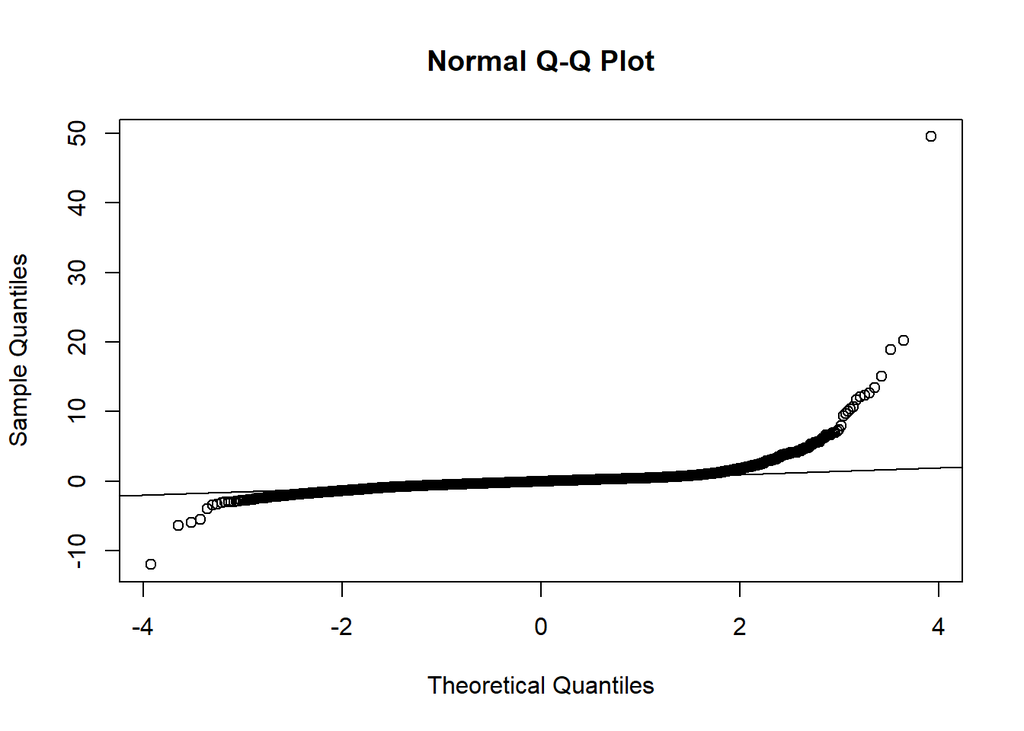

```r
houses.glm1.res <- rstandard(houses.glm1)
qqnorm(houses.glm1.res)
qqline(houses.glm1.res)
```

## 2.1 Initial Model Remarks

- A percent error of ~39.9% is not great, so hopefully I can create a better model later on
- The Q-Q plot shows heavy tails off of the normal line, especially on the right
  - This implies that the ‘Price’ variable is not normally distributed enough with many outliers (especially high outliers)
  - Perhaps removing these outliers and/or transforming Price could help
- the Bedrooms variable is oddly assigned a negative (and significant) correlation with Price, which is counter-intuitive since more bedrooms would seem to imply high cost
- multiple Property Type categories are deemed to have insignificant difference from “House”, perhaps I can reduce the number of categories or fix them some other way
- Saskatchewan is not significant and Manitoba is just barely, perhaps they have similar distributions so I can merge these together?

# 3 Augmenting the Variables

In this section I will begin augmenting the variables of my dataframe through transformation or dataframe manipulation in order to better fit the assumptions of the generalized linear model.

## 3.1 Price

### 3.1.1 Investigating the Variable

Since Price is the response variable of our model, it will be the most important one to have normally distributed for my glm. Let’s begin by creating a density plot to see the current distribution:

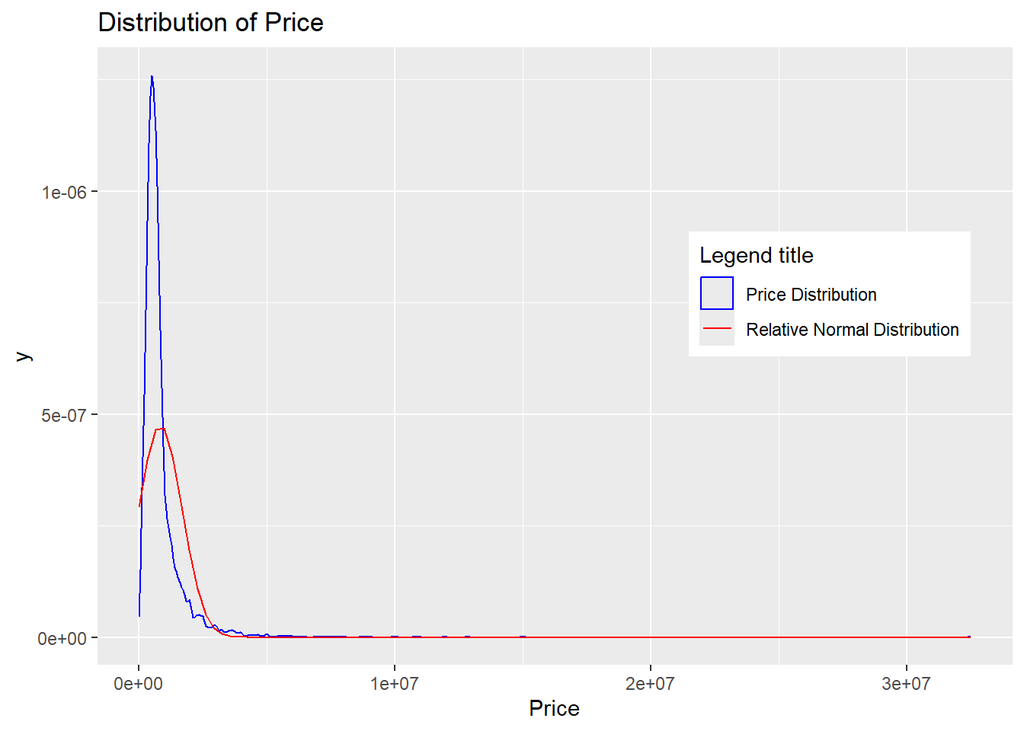

```r
#' Creates a distribution plot object with relative normal distribution
#'
#' @param df A Dataframe
#' @param column A string representing a column name
#' @param datatype A string denoting plot type
#' @return distribution plot
distribution_graph <- function(df, column, datatype="bar") {
  y <- if(datatype=="density"){
    geom_density(aes(colour=paste(column,"Distribution")))
    } else {geom_bar(aes(colour=paste(column,"Distribution")))}
  p <- ggplot(data=df, aes(x=.data[[column]])) +
    ggtitle(paste("Distribution of", column)) + y +
    stat_function(fun=dnorm, aes(colour = "Relative Normal Distribution"),
                  args=list(mean=mean(df[[column]]), sd=sd(df[[column]]))) +
    scale_colour_manual("Legend title", values = c("blue", "red")) +
    theme(legend.position="inside", legend.position.inside = c(0.8, 0.6))
  return(p)
}
# Create the plot
distribution_graph(houses.df, "Price", datatype="density")
```

As was already seen in the naive model’s Q-Q plot, the distribution of prices in our dataset is not very normal. There is a very heavy right-sided tail which makes this density curve much thinner than the relative normal curve that it should be. However, this should be easily fixed by a simple log transformation on Price:

### 3.1.2 Assessing Changes

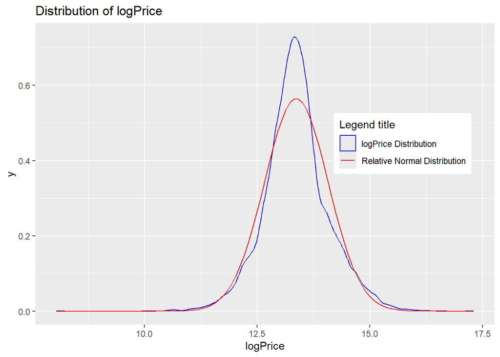

```r
## Create new "log(Price)" column for dataset and replot:
houses.df$logPrice <- log(houses.df$Price)
distribution_graph(houses.df, "logPrice", datatype="density")
```

This log transformation of Price seems to fit the normality assumption significantly better than before, so it will be used in place of Price. I will also remove all listings with extreme logPrice to cut down on tails.

### 3.1.3 Testing New Model

Let’s recreate the model with my change and compare with the previous model.

```r
# Removing outlying logPrices, and making second model:
q99.9 <- quantile(houses.df$logPrice, probs=c(0.0005,0.9995))
houses.df <- houses.df %>% filter(logPrice > q99.9[1]) %>% filter(logPrice < q99.9[2])
houses.glm2 <- glm(formula = logPrice~Bedrooms+Bathrooms+SquareFeet+PropertyType+Province+Population,
                   data=houses.df)
my_summary(houses.glm2, "Model 2")
```

```
## " Model 2 "
## Formula:  logPrice ~ Bedrooms + Bathrooms + SquareFeet + PropertyType + Province + Population
##
##                                Estimate  Std. Error  t value  Pr(>|t|)
## (Intercept)                  1.2493e+01  1.2959e-02 964.0403 < 2.2e-16 ***
## Bedrooms                    -1.8739e-02  3.0778e-03  -6.0884 1.177e-09 ***
## Bathrooms                    1.2924e-01  4.2974e-03  30.0743 < 2.2e-16 ***
## SquareFeet                   2.2126e-04  6.0454e-06  36.5994 < 2.2e-16 ***
## PropertyTypeApt/Condo       -3.6435e-01  1.0058e-02 -36.2255 < 2.2e-16 ***
## PropertyTypeTownhouse       -2.8766e-01  1.0253e-02 -28.0575 < 2.2e-16 ***
## PropertyTypeDuplex          -7.8068e-02  1.7514e-02  -4.4575 8.371e-06 ***
## PropertyTypeMfd/Mobile Home -1.0921e+00  3.6053e-02 -30.2916 < 2.2e-16 ***
## PropertyTypeMultifamily     -9.5957e-02  4.2564e-02  -2.2544  0.024190 *
## PropertyTypeFourplex        -2.7892e-01  1.0445e-01  -2.6705  0.007585 **
## PropertyTypeLand/Lot        -2.6726e-01  1.0940e-01  -2.4430  0.014580 *
## PropertyTypeTriplex         -1.3206e-01  1.1532e-01  -1.1452  0.252145
## PropertyTypeRecreational    -9.1016e-02  1.9948e-01  -0.4563  0.648205
## ProvinceBritish Columbia     8.6612e-01  9.8333e-03  88.0806 < 2.2e-16 ***
## ProvinceManitoba            -2.5346e-01  1.6517e-02 -15.3459 < 2.2e-16 ***
## ProvinceNew Brunswick       -2.5691e-01  1.6306e-02 -15.7561 < 2.2e-16 ***
## ProvinceOntario              4.3510e-01  9.5518e-03  45.5519 < 2.2e-16 ***
## ProvinceSaskatchewan        -2.4502e-01  1.2877e-02 -19.0277 < 2.2e-16 ***
## Population                   1.2387e-07  4.9545e-09  25.0023 < 2.2e-16 ***
## ---
## Signif. codes:  0 '***' 0.001 '**' 0.01 '*' 0.05 '.' 0.1 ' ' 1
##
## AIC: 8057.41698569695
```

```r
pred <- exp(predict(houses.glm2, houses.df))
error(pred, houses.df$Price)
```

```
## [1] 0.307084
```

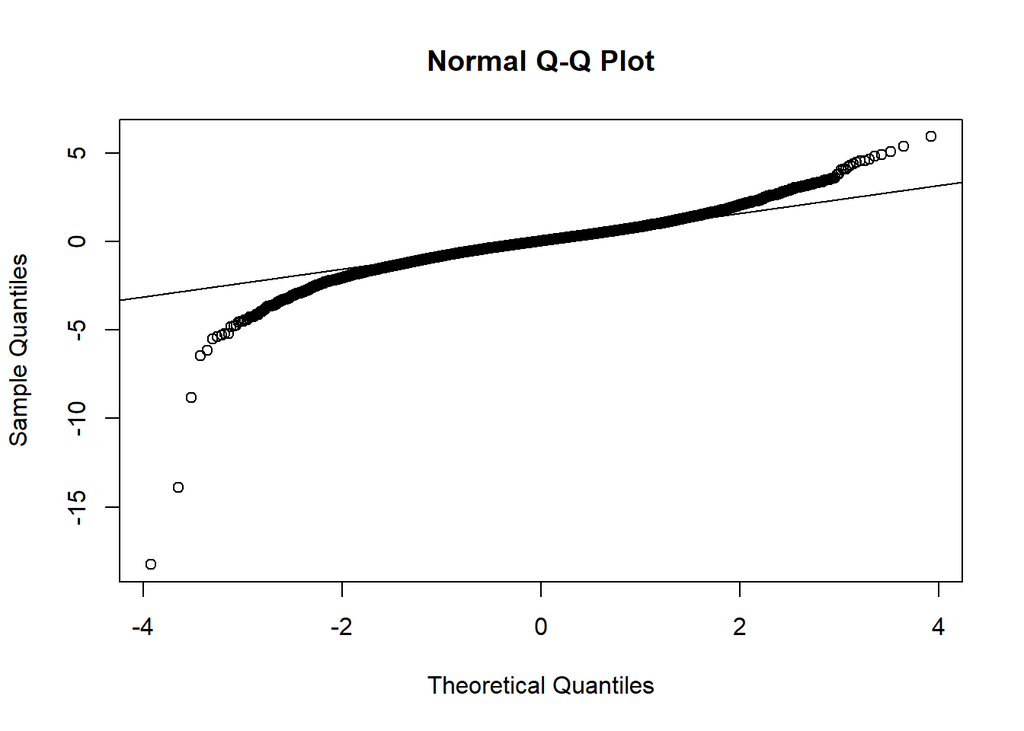

```r
houses.glm2.res <- rstandard(houses.glm2)
qqnorm(houses.glm2.res)
qqline(houses.glm2.res)
```

### Remarks

Overall, the model has improved in many ways and logPrice will be used in all future models.

## 3.2 Property Type

### 3.2.1 Investigating the Variable

Let’s check the various property types and their distributions so we can see which ones are similar enough to be grouped, or scarce enough to be removed.

```r
houses.df %>% group_by(PropertyType) %>% summarise(count=n())
```

```
## # A tibble: 10 × 2
##    PropertyType    count
##    <fct>           <int>
##  1 House            6002
##  2 Apt/Condo        2988
##  3 Townhouse        1688
##  4 Duplex            439
##  5 Mfd/Mobile Home    95
##  6 Multifamily        69
##  7 Fourplex           11
##  8 Land/Lot           10
##  9 Triplex             9
## 10 Recreational        3
```

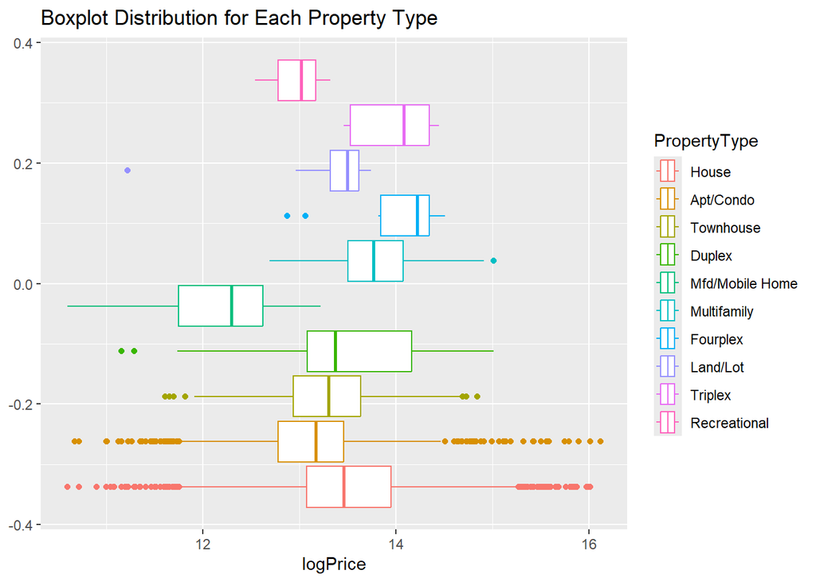

```r
ggplot(data=houses.df, aes(x=logPrice, color=PropertyType)) +
  geom_boxplot() + ggtitle("Boxplot Distribution for Each Property Type")
```

Firstly the ‘Land/Lot’ and ‘Recreational’ categories are very scarce. Since ‘Land/Lot’ isn’t really a kind of housing, I will simply remove any of these listings. ‘Recreational’ is also an odd type of housing and it has no similar categories, so it too will be removed.

Secondly since Triplex, Fourplex, and Multifamily are all on the higher end of the plot and are similar categories anyways, I will consider combining them (and perhaps other categories) after performing an ANOVA and a Tukey HCD test.

```r
# removing 'Land/Lot' and 'Recreational' listings
houses.df <- houses.df %>%
  filter(!(PropertyType %in% c("Land/Lot","Recreational")))
houses.df$PropertyType <- droplevels(houses.df$PropertyType)
```

```r
## ANOVA test
anova_model <- aov(logPrice ~ PropertyType, data = houses.df)
summary(anova_model)
```

```
##                 Df Sum Sq Mean Sq F value Pr(>F)
## PropertyType     7    481   68.65   154.2 <2e-16 ***
## Residuals    11293   5026    0.45
## ---
## Signif. codes:  0 '***' 0.001 '**' 0.01 '*' 0.05 '.' 0.1 ' ' 1
```

Clearly there is significant difference between categories, but it was good to check anyway.

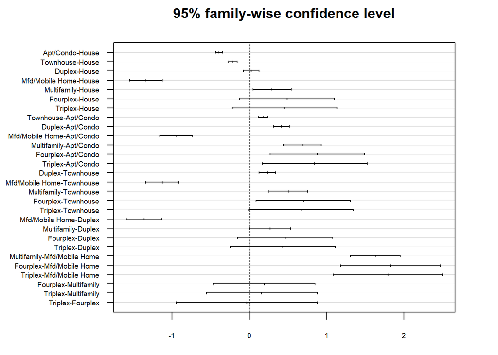

```r
## Tukey HCD test
tukey_results <- TukeyHSD(anova_model,conf.level = 0.95)
par(mar=c(3,8,3,3))
plot(tukey_results, las=1, cex.axis = 0.6)
```

Looking at which categories are/aren’t significantly different in their mean, I can make some remarks:

- Triplex, Fourplex, and Multifamily are all considered to not have significantly different means as expected.
- However Duplex is also considered to not have significantly different mean than these categories
- House is similar to Duplex in this regard, but IS significantly different from Multifamily
- House and Duplex both have similar distributions, and their means aren’t significantly different

### 3.2.2 Making & Assessing Changes

Since Triplex, Fourplex, and Multifamily are so similar, I will try combining them into one category. Then I will re-plot and assess the changes.

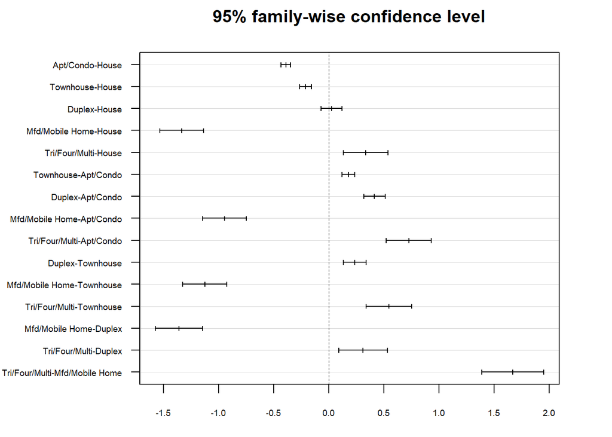

```r
# Merging categories
houses.df$PropertyType <-
  fct_collapse(houses.df$PropertyType,
               `Tri/Four/Multi` = c("Triplex","Fourplex","Multifamily"))
## Tukey HCD test
anova_model <- aov(logPrice ~ PropertyType, data = houses.df)
tukey_results <- TukeyHSD(anova_model,conf.level = 0.95)
par(mar=c(3,8,3,3))
plot(tukey_results, las=1, cex.axis = 0.6)
```

It seems that the new category ‘Tri/Four/Multi’ has a mean significantly different from that of ‘Duplex’, so I will not be merging these categories. However the ‘Duplex’ and ‘House’ categories are still similar in mean (and distribution), so I will create two models: one with ‘House’ and ‘Duplex’ as separate categories, and one with them merged. Afterwards I will compare models and pick the one I find most suitable.

### 3.2.3 Testing New Models

Let’s recreate the model with my change and compare with the previous model.

```r
# Making model with House and Duplex separate
houses.glm3.1 <- glm(formula = logPrice~Bedrooms+Bathrooms+SquareFeet+PropertyType+Province+Population,
                     data=houses.df)
# Making model with House and Duplex merged
houses.df.2 <- houses.df
houses.df.2$PropertyType <-
  fct_collapse(houses.df.2$PropertyType,
               `House/Duplex` = c("House","Duplex"))
houses.glm3.2 <- glm(formula = logPrice~Bedrooms+Bathrooms+SquareFeet+PropertyType+Province+Population,
                     data=houses.df.2)
my_summary(houses.glm3.1, "Separate House/Duplex")
```

```
## " Separate House/Duplex "
## Formula:  logPrice ~ Bedrooms + Bathrooms + SquareFeet + PropertyType + Province + Population
##
##                                Estimate  Std. Error  t value  Pr(>|t|)
## (Intercept)                  1.2493e+01  1.2963e-02 963.7412 < 2.2e-16 ***
## Bedrooms                    -1.8742e-02  3.0777e-03  -6.0898 1.168e-09 ***
## Bathrooms                    1.2937e-01  4.3010e-03  30.0805 < 2.2e-16 ***
## SquareFeet                   2.2120e-04  6.0473e-06  36.5788 < 2.2e-16 ***
## PropertyTypeApt/Condo       -3.6400e-01  1.0056e-02 -36.1974 < 2.2e-16 ***
## PropertyTypeTownhouse       -2.8756e-01  1.0248e-02 -28.0593 < 2.2e-16 ***
## PropertyTypeDuplex          -7.7963e-02  1.7505e-02  -4.4537 8.521e-06 ***
## PropertyTypeMfd/Mobile Home -1.0919e+00  3.6037e-02 -30.2992 < 2.2e-16 ***
## PropertyTypeTri/Four/Multi  -1.2247e-01  3.7575e-02  -3.2592  0.001121 **
## ProvinceBritish Columbia     8.6570e-01  9.8270e-03  88.0942 < 2.2e-16 ***
## ProvinceManitoba            -2.5185e-01  1.6527e-02 -15.2387 < 2.2e-16 ***
## ProvinceNew Brunswick       -2.5666e-01  1.6299e-02 -15.7476 < 2.2e-16 ***
## ProvinceOntario              4.3551e-01  9.5409e-03  45.6470 < 2.2e-16 ***
## ProvinceSaskatchewan        -2.4525e-01  1.2870e-02 -19.0563 < 2.2e-16 ***
## Population                   1.2368e-07  4.9521e-09  24.9748 < 2.2e-16 ***
## ---
## Signif. codes:  0 '***' 0.001 '**' 0.01 '*' 0.05 '.' 0.1 ' ' 1
##
## AIC: 8033.54171166601
```

```r
my_summary(houses.glm3.2, "Merged House/Duplex")
```

```
## " Merged House/Duplex "
## Formula:  logPrice ~ Bedrooms + Bathrooms + SquareFeet + PropertyType + Province + Population
##
##                                Estimate  Std. Error  t value  Pr(>|t|)
## (Intercept)                  1.2486e+01  1.2865e-02 970.5269 < 2.2e-16 ***
## Bedrooms                    -1.8741e-02  3.0803e-03  -6.0841  1.21e-09 ***
## Bathrooms                    1.2744e-01  4.2825e-03  29.7582 < 2.2e-16 ***
## SquareFeet                   2.2455e-04  6.0055e-06  37.3907 < 2.2e-16 ***
## PropertyTypeApt/Condo       -3.5683e-01  9.9345e-03 -35.9182 < 2.2e-16 ***
## PropertyTypeTownhouse       -2.8077e-01  1.0143e-02 -27.6820 < 2.2e-16 ***
## PropertyTypeMfd/Mobile Home -1.0854e+00  3.6037e-02 -30.1185 < 2.2e-16 ***
## PropertyTypeTri/Four/Multi  -1.1924e-01  3.7600e-02  -3.1714  0.001521 **
## ProvinceBritish Columbia     8.6452e-01  9.8316e-03  87.9327 < 2.2e-16 ***
## ProvinceManitoba            -2.5138e-01  1.6540e-02 -15.1978 < 2.2e-16 ***
## ProvinceNew Brunswick       -2.5155e-01  1.6272e-02 -15.4592 < 2.2e-16 ***
## ProvinceOntario              4.4010e-01  9.4930e-03  46.3603 < 2.2e-16 ***
## ProvinceSaskatchewan        -2.4000e-01  1.2826e-02 -18.7112 < 2.2e-16 ***
## Population                   1.2257e-07  4.9499e-09  24.7614 < 2.2e-16 ***
## ---
## Signif. codes:  0 '***' 0.001 '**' 0.01 '*' 0.05 '.' 0.1 ' ' 1
##
## AIC: 8051.38614317299
```

```r
pred.1 <- exp(predict(houses.glm3.1, houses.df))
error(pred.1, houses.df$Price)
```

```
## [1] 0.3068904
```

```r
pred.2 <- exp(predict(houses.glm3.2, houses.df.2))
error(pred.2, houses.df$Price)
```

```
## [1] 0.3079341
```

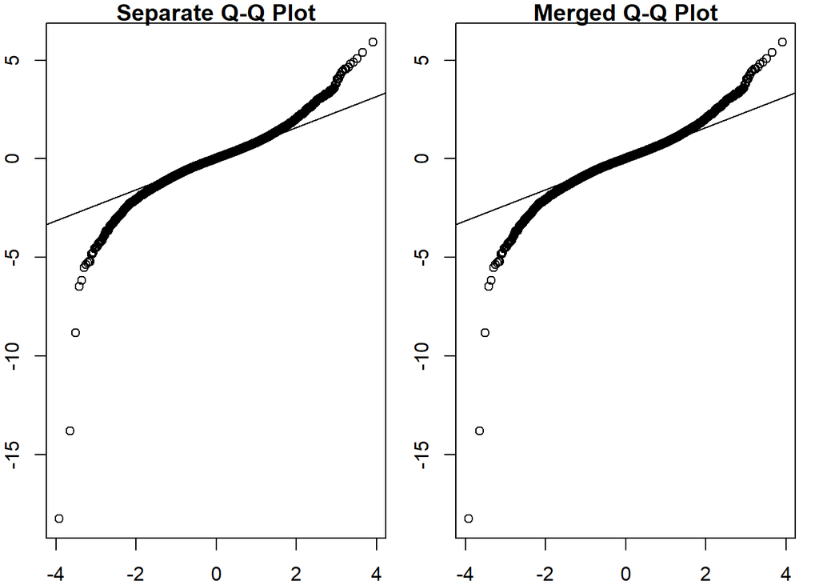

```r
par(mar=c(2,2,1,1), mfrow = c(1, 2))
houses.glm3.1.res <- rstandard(houses.glm3.1)
qqnorm(houses.glm3.1.res, ylab = "", xlab = "", main="Separate Q-Q Plot")
qqline(houses.glm3.1.res)

houses.glm3.2.res <- rstandard(houses.glm3.1)
qqnorm(houses.glm3.2.res, ylab = "", xlab = "", main="Merged Q-Q Plot")
qqline(houses.glm3.2.res)
```

### Remarks

```r
# Choosing official 3rd model
houses.glm3 <- houses.glm3.1
```

## 3.3 Province

Now I will move onto the other categorical variable in my model: Province. I will be assessing the 6 different provinces in my model and seeing if any changes will be appropriate to help the model.

```r
houses.df %>% group_by(Province) %>% summarise(count=n())
```

```
## # A tibble: 6 × 2
##   Province         count
##   <chr>            <int>
## 1 Alberta           2505
## 2 British Columbia  3364
## 3 Manitoba           541
## 4 New Brunswick      629
## 5 Ontario           3194
## 6 Saskatchewan      1068
```

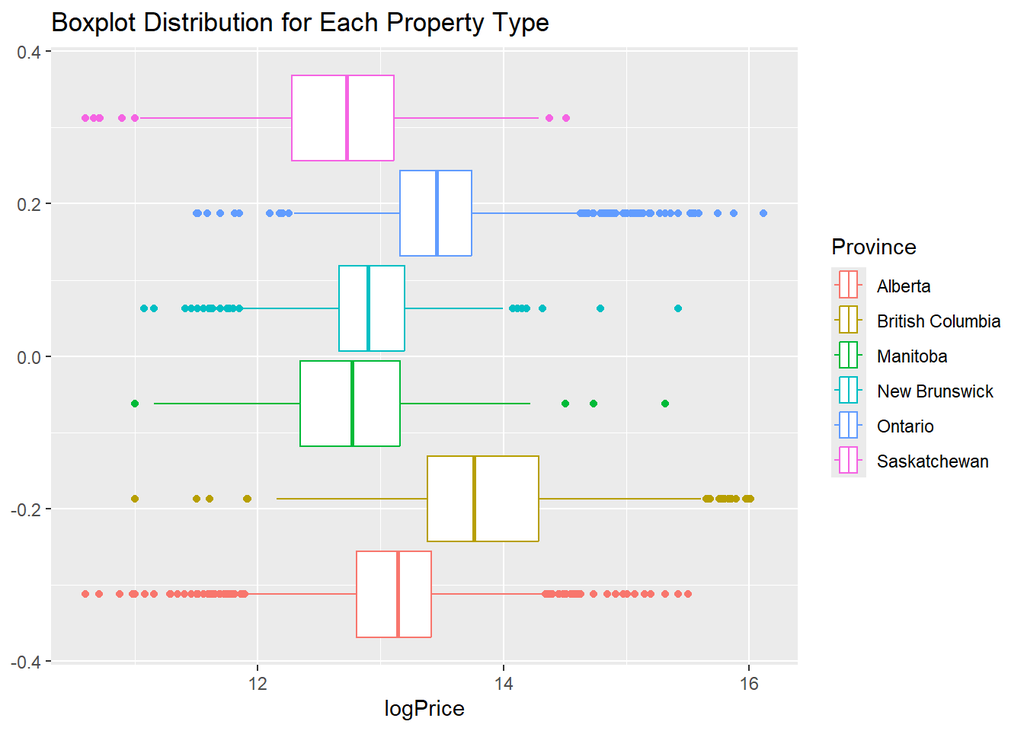

```r
ggplot(data=houses.df, aes(x=logPrice, color=Province)) +
  geom_boxplot() + ggtitle("Boxplot Distribution for Each Property Type")
```

The boxplot distributions of Saskatchewan and Manitoba seem very similar, so I will see if it is reasonable to merge these provinces. New Brunswick also has a somewhat similar distribution. Each of the other provinces have quite unique distributions, so it is unlikely that they are not significantly different. Regardless, I will check with an ANOVA test:

```r
## ANOVA test
anova_model <- aov(logPrice ~ Province, data = houses.df)
summary(anova_model)
```

```
##                Df Sum Sq Mean Sq F value Pr(>F)
## Province        5   1837   367.5    1131 <2e-16 ***
## Residuals   11295   3670     0.3
## ---
## Signif. codes:  0 '***' 0.001 '**' 0.01 '*' 0.05 '.' 0.1 ' ' 1
```

Of course it finds significant statistical difference, so I will perform a Tukey HCD test to see if any of my proposed merges would be reasonable.

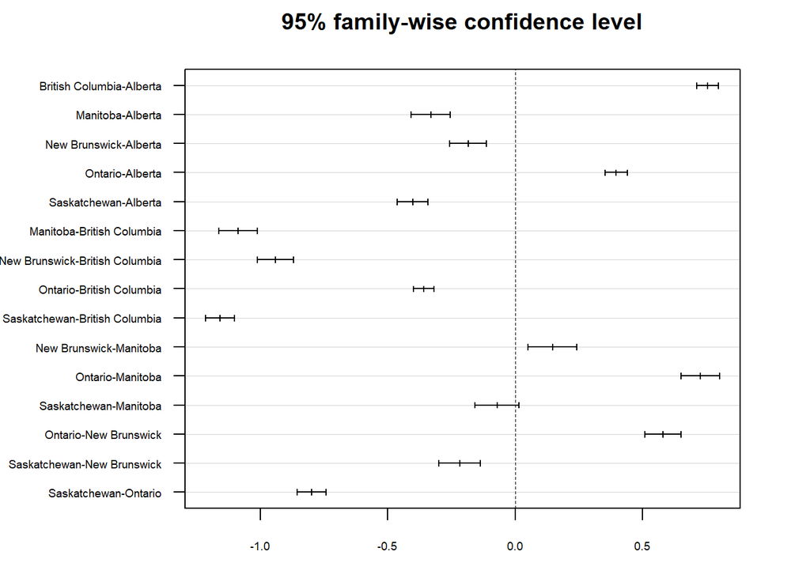

```r
## Tukey HCD test
tukey_results <- TukeyHSD(anova_model,conf.level = 0.95)
par(mar=c(3,8,3,3))
plot(tukey_results, las=1, cex.axis = 0.6)
```

Saskatchewan and Manitoba are still not determined to be significantly different, and so I will attempt to merge these. Since nothing else is even closely related, I will not reassess with another Tukey HCD test.

```r
# Merging categories
houses.df$Province <-
  fct_collapse(houses.df$Province,
               `Saskatchewan/Manitoba` = c("Saskatchewan","Manitoba"))
houses.glm4 <- glm(formula = logPrice~Bedrooms+Bathrooms+SquareFeet+PropertyType+Province+Population,
                   data=houses.df)
my_summary(houses.glm4, "Model 4")
```

```
## " Model 4 "
## Formula:  logPrice ~ Bedrooms + Bathrooms + SquareFeet + PropertyType + Province + Population
##
##                                  Estimate  Std. Error  t value  Pr(>|t|)
## (Intercept)                    1.2493e+01  1.2962e-02 963.7932 < 2.2e-16 ***
## Bedrooms                      -1.8725e-02  3.0772e-03  -6.0852 1.202e-09 ***
## Bathrooms                      1.2944e-01  4.2972e-03  30.1217 < 2.2e-16 ***
## SquareFeet                     2.2112e-04  6.0430e-06  36.5918 < 2.2e-16 ***
## PropertyTypeApt/Condo         -3.6388e-01  1.0050e-02 -36.2073 < 2.2e-16 ***
## PropertyTypeTownhouse         -2.8744e-01  1.0243e-02 -28.0625 < 2.2e-16 ***
## PropertyTypeDuplex            -7.8329e-02  1.7475e-02  -4.4824 7.455e-06 ***
## PropertyTypeMfd/Mobile Home   -1.0921e+00  3.6030e-02 -30.3112 < 2.2e-16 ***
## PropertyTypeTri/Four/Multi    -1.2249e-01  3.7574e-02  -3.2599  0.001118 **
## ProvinceBritish Columbia       8.6563e-01  9.8247e-03  88.1077 < 2.2e-16 ***
## ProvinceSaskatchewan/Manitoba -2.4751e-01  1.1223e-02 -22.0534 < 2.2e-16 ***
## ProvinceNew Brunswick         -2.5672e-01  1.6297e-02 -15.7521 < 2.2e-16 ***
## ProvinceOntario                4.3555e-01  9.5401e-03  45.6543 < 2.2e-16 ***
## Population                     1.2345e-07  4.9106e-09  25.1394 < 2.2e-16 ***
## ---
## Signif. codes:  0 '***' 0.001 '**' 0.01 '*' 0.05 '.' 0.1 ' ' 1
##
## AIC: 8031.66987019573
```

```r
pred <- exp(predict(houses.glm4, houses.df))
error(pred, houses.df$Price)
```

```
## [1] 0.3069188
```

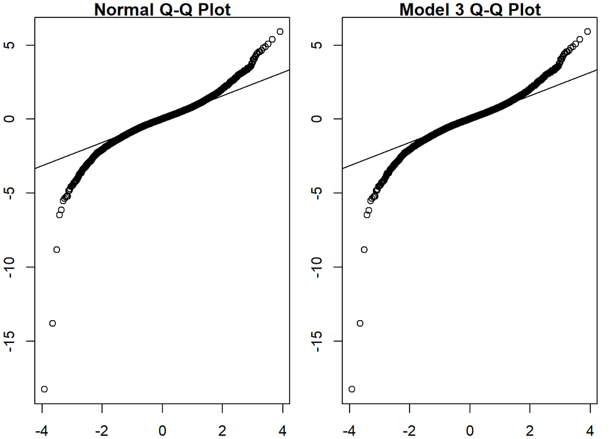

```r
par(mar=c(2,2,1,1), mfrow = c(1, 2))
houses.glm4.res <- rstandard(houses.glm4)
qqnorm(houses.glm4.res)
qqline(houses.glm4.res, main="Model 4 Q-Q Plot")
qqnorm(houses.glm3.1.res, main="Model 3 Q-Q Plot")
qqline(houses.glm3.1.res)
```

### Remarks

- The AIC has reduced by about 2
  - This supports the idea that these provinces were not introducing different enough correlation
- The error rate increases by about 0.00003
- Same as the other statistics, the QQ-plot did not change in a very significant way.

Though the affects of this province merging are small, I believe that a decrease of 2 in AIC is of greater importance than a minuscule increase in the error rate. Thus I will be using this new model moving forward.

## 3.4 Numerical Explanatory Variables

Let’s move on to dealing with the explanatory variables with numerical values like Bathrooms, Bedrooms, and SquareFeet. Besides improving the model, I am hoping I will be able to make use the ‘Bedrooms’ variable in some significant (and positive) way.

### 3.4.1 Finding Outliers

Let’s start by trimming the data for any outliers, beginning with Bedrooms:

First I will remove any listings with a zero value for Bedrooms, Bathrooms, or SquareFeet. Zero bedrooms or bathrooms is hardly a living space, and zero square feet is nothing.

```r
houses.df <- houses.df %>%
  filter(Bedrooms != 0) %>%
  filter(Bathrooms != 0) %>%
  filter(SquareFeet != 0)
```

```r
# Removing outlying Bedrooms:
q99.9 <- quantile(houses.df$Bedrooms, probs=c(0.0005,0.9995))
q99.9
```

```
##  0.05% 99.95%
##      1     15
```

```r
table(houses.df$Bedrooms)
```

```
##
##    1    2    3    4    5    6    7    8    9   10   11   12   13   14   15   16
##  979 2709 3431 2285 1118  437  138   60   32   15    6    6    1    2    2    2
##   25   28   43
##    1    1    1
```

```r
# Let's view these listings:
print(filter(houses.df, Bedrooms >= q99.9[2]), n=Inf)
```

```
## # A tibble: 7 × 9
##   Province    City   Price Bedrooms Bathrooms SquareFeet PropertyType Population
##   <fct>       <chr>  <dbl>    <dbl>     <dbl>      <dbl> <fct>             <dbl>
## 1 Ontario     kitc… 1.00e7       43        35      26000 Apt/Condo        337811
## 2 Ontario     wate… 1.87e6       15         6       4500 Tri/Four/Mu…     152118
## 3 Ontario     wate… 1.5 e6       16         6       4244 Tri/Four/Mu…     152118
## 4 Ontario     wate… 3.65e6       28        17      10697 Apt/Condo        152118
## 5 Ontario     lond… 1.30e6       16         6       3500 Tri/Four/Mu…     509102
## 6 Ontario     hami… 5.70e6       25        20      17080 Apt/Condo        649392
## 7 British Co… surr… 2.00e6       15        12       4549 House            736057
## # ℹ 1 more variable: logPrice <dbl>
```

I will manually going through these listings to see if there are any actual problems to determine if I will keep them

- 1: This listing turns out to be a listing for an entire apartment complex. Since I intend to estimate individual listings, this item doesn’t fit in my dataset and will be removed.
- 2: This listing is quite odd. It is a multi-family residence packed chock-full of bedrooms and not much else. However, since I can’t find anything actually incorrect about the listing, I will keep it.
- 3: Same as item 2, just an odd multifamily listing.
- 4: This is another listing that represents an entire apartment complex.
- 5: Odd multifamily listing.
- 6: Apartment complex listing.
- 7: After finding what I believe to be this listing. I think that there was either an error in my scraping, or the online listing was changed since yesterday. The listing I found matched everything except the bedroom and bathroom counts were 8 and 5 respectively. I will change this.

```r
houses.df[which(houses.df$Bedrooms == 15 & houses.df$Bathrooms == 12),]$Bedrooms <- 8
houses.df[which(houses.df$Bedrooms == 8 & houses.df$Bathrooms == 12),]$Bathrooms <- 5
```

Now I will check for more apartment complexes:

```r
houses.df %>%
  filter(PropertyType == 'Apt/Condo') %>%
  filter(Bedrooms >= 5)
```

```
## # A tibble: 17 × 9
##    Province   City   Price Bedrooms Bathrooms SquareFeet PropertyType Population
##    <fct>      <chr>  <dbl>    <dbl>     <dbl>      <dbl> <fct>             <dbl>
##  1 Ontario    kitc… 1.00e7       43        35      26000 Apt/Condo        337811
##  2 Ontario    wate… 5.29e5        5         2       1399 Apt/Condo        152118
##  3 Ontario    wate… 6.59e5        5         4       1799 Apt/Condo        152118
##  4 Ontario    wate… 5.25e5        5         2       1399 Apt/Condo        152118
##  5 Ontario    wate… 5.39e5        5         2       1399 Apt/Condo        152118
##  6 Ontario    wate… 7.40e5        5         5       2249 Apt/Condo        152118
##  7 Ontario    wate… 5.6 e5        5         2       1399 Apt/Condo        152118
##  8 Ontario    wate… 3.65e6       28        17      10697 Apt/Condo        152118
##  9 Ontario    wate… 5.70e5        5         2       1158 Apt/Condo        152118
## 10 Ontario    wate… 5.80e5        5         2       1399 Apt/Condo        152118
## 11 Ontario    wate… 8.89e5        5         5       2104 Apt/Condo        152118
## 12 Ontario    wate… 5.70e5        5         2       1389 Apt/Condo        152118
## 13 Ontario    wate… 5.69e5        5         2       1199 Apt/Condo        152118
## 14 Ontario    wate… 5.89e5        5         2       1200 Apt/Condo        152118
## 15 Ontario    hami… 5.70e6       25        20      17080 Apt/Condo        649392
## 16 British C… coqu… 2.29e6        5         3       3675 Apt/Condo        180845
## 17 Alberta    edmo… 7.29e5        5         5       2024 Apt/Condo       1243809
## # ℹ 1 more variable: logPrice <dbl>
```

After some investigation, it seems that those 3 outliers identified beforehand were the only apartment complex listings in the whole dataset. I will remove them now.

```r
houses.df <- houses.df %>%
  filter(!(PropertyType=='Apt/Condo' & Bedrooms > 5))
```

### 3.4.2 Bathrooms

```r
# Removing outlying Bathrooms:
q99.9 <- quantile(houses.df$Bathrooms, probs=c(0.0005,0.9995))
q99.9
```

```
##  0.05% 99.95%
##      1     10
```

```r
table(houses.df$Bathrooms)
```

```
##
##    1    2    3    4    5    6    7    8    9   10   11   12   26
## 2045 3911 3092 1609  298  140   72   32   14    7    1    1    1
```

```r
# Let's view these listings:
print(filter(houses.df, Bathrooms >= q99.9[2]), n=Inf)
```

```
## # A tibble: 10 × 9
##    Province   City   Price Bedrooms Bathrooms SquareFeet PropertyType Population
##    <fct>      <chr>  <dbl>    <dbl>     <dbl>      <dbl> <fct>             <dbl>
##  1 Ontario    lond… 3.00e6       12        26      16000 Tri/Four/Mu…     509102
##  2 Ontario    otta… 2.70e6       10        10       5000 Tri/Four/Mu…    1196385
##  3 Ontario    hami… 1.55e6       13        10       6316 Tri/Four/Mu…     649392
##  4 Ontario    hami… 3.00e6       12        10       7644 Tri/Four/Mu…     649392
##  5 British C… vanc… 3.69e6       11        10       4193 House            776584
##  6 British C… burn… 3.49e6        8        10       4985 House            310666
##  7 British C… burn… 3.30e6       10        11       5157 House            310666
##  8 British C… rich… 4.70e6       10        10      10998 House            250915
##  9 Alberta    edmo… 1.70e6       10        12       3519 Tri/Four/Mu…    1243809
## 10 Alberta    edmo… 1.99e6        7        10       5137 House           1243809
## # ℹ 1 more variable: logPrice <dbl>
```

After checking through these listings, all of them were valid except for listing 1. Despite only scraping yesterday I couldn’t find any listing that was close to this one, even on other realty websites. Unfortunately, I will have to remove this listing for this reason.

```r
houses.df <- houses.df %>%
  filter(!(Bathrooms > 20))
```

### 3.4.3 Square Feet

```r
# Removing outlying Square Footage:
q99.9 <- quantile(houses.df$SquareFeet, probs=c(0.0005,0.9995))
q99.9
```

```
##    0.05%   99.95%
##  414.000 8434.682
```

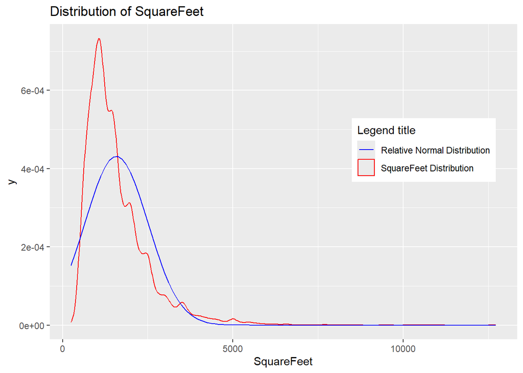

```r
distribution_graph(houses.df, "SquareFeet", "density")
```

```r
# Let's view these listings:
print(filter(houses.df, SquareFeet <= q99.9[1]), n=Inf)
```

```
## # A tibble: 7 × 9
##   Province    City   Price Bedrooms Bathrooms SquareFeet PropertyType Population
##   <fct>       <chr>  <dbl>    <dbl>     <dbl>      <dbl> <fct>             <dbl>
## 1 Ontario     hami… 199900        1         1        411 Apt/Condo        649392
## 2 British Co… vanc… 479900        1         1        414 Apt/Condo        776584
## 3 British Co… vict… 413000        1         1        414 Apt/Condo        106112
## 4 British Co… vict… 478000        1         1        385 Apt/Condo        106112
## 5 Alberta     calg… 294000        1         1        401 Apt/Condo       1634686
## 6 New Brunsw… monc… 359900        3         2        247 House            102571
## 7 New Brunsw… sain… 110000        1         1        300 House             80016
## # ℹ 1 more variable: logPrice <dbl>
```

After manual inspection each of these listings seem valid, except for listing 6. I see two very similar listings online, so I will need to check my dataset first.

```r
filter(houses.df, Price == 359900 & City == 'moncton-nb' & Bedrooms == 3)
```

```
## # A tibble: 2 × 9
##   Province    City   Price Bedrooms Bathrooms SquareFeet PropertyType Population
##   <fct>       <chr>  <dbl>    <dbl>     <dbl>      <dbl> <fct>             <dbl>
## 1 New Brunsw… monc… 359900        3         2       1500 House            102571
## 2 New Brunsw… monc… 359900        3         2        247 House            102571
## # ℹ 1 more variable: logPrice <dbl>
```

There are two listings that are almost the exact same in my dataset, and online it is the same. However the online listings show square feet of 1500 and 1400, rather than 1500 and 247. I will simply change this listing manually in my dataset.

```r
houses.df[which(houses.df$SquareFeet == 247),]$SquareFeet <- 1400
```

```r
print(filter(houses.df, SquareFeet >= q99.9[2]), n=Inf)
```

```
## # A tibble: 6 × 9
##   Province    City   Price Bedrooms Bathrooms SquareFeet PropertyType Population
##   <fct>       <chr>  <dbl>    <dbl>     <dbl>      <dbl> <fct>             <dbl>
## 1 British Co… surr… 7.30e6        6         8       8616 House            736057
## 2 British Co… surr… 7.69e6        5         7       9500 House            736057
## 3 British Co… surr… 6.98e6        8         9      10643 House            736057
## 4 British Co… rich… 8.80e6        9         9      12724 House            250915
## 5 British Co… rich… 4.70e6       10        10      10998 House            250915
## 6 New Brunsw… sain… 4.99e6        5         6      10200 House             80016
## # ℹ 1 more variable: logPrice <dbl>
```

Couldn’t find anything wrong with these!

```r
cor(houses.df[,3:6])
```

```
##                Price  Bedrooms Bathrooms SquareFeet
## Price      1.0000000 0.4473143 0.5797428  0.7008696
## Bedrooms   0.4473143 1.0000000 0.7132993  0.6858489
## Bathrooms  0.5797428 0.7132993 1.0000000  0.7720384
## SquareFeet 0.7008696 0.6858489 0.7720384  1.0000000
```

```r
# pairs(houses.df[,c(3:6)])
```